# Introduction

Can machine learning be used to Identify Fraud in Enron? Using emails and financial data released during the Federal investigation, we’ll attempt to identify executives that were persons of interest using machine learning. A person of interest (POI) is defined as a person who was indicted for fraud, settled with the government, or testified in exchange for immunity.

First, a brief background on Enron,before filing for bankruptcy in 2001, Enron Corporation was one of the largest integrated natural gas and electricity companies in the world. It marketed natural gas liquids worldwide and operated one of the largest natural gas transmission systems in the world, totaling more than 36,000 miles. It was also one of the largest independent developers and producers of electricity in the world, serving both industrial and emerging markets. Enron was also a major supplier of solar and wind renewable energy worldwide, managed the largest portfolio of natural gas-related risk management contracts in the world, and was one of the world's biggest independent oil and gas exploration companies. In North America, Enron was the largest wholesale marketer of natural gas and electricity. Enron pioneered innovative trading products, such as gas futures and weather futures, significantly modernizing the utilities industry. After a surge of growth in the early 1990s, the company ran into difficulties. The magnitude of Enron's losses was hidden from stockholders. The company folded after a failed merger deal with Dynegy Inc. in 2001 brought to light massive financial finagling. The company had ranked number seven on the Fortune 500, and its failure was the biggest bankruptcy in American history.

```python
%matplotlib inline
#%pprint ON
import sys
import pickle
import numpy as np
import pandas as pd
import matplotlib.pyplot as plt

sys.path.append("../tools/")

from feature_format import featureFormat, targetFeatureSplit
from tester import test_classifier, dump_classifier_and_data

## Determine Best features
from sklearn.feature_selection import SelectKBest
from sklearn.feature_selection import f_classif,f_regression


## Classifiers
from sklearn.svm import LinearSVC
from sklearn.naive_bayes import GaussianNB


## Pipeline
from sklearn.pipeline import Pipeline, FeatureUnion

## Scalers
from sklearn.preprocessing import StandardScaler

## Component Reduction
from sklearn.lda import LDA
from sklearn.decomposition import PCA
from check import output_classifier



## Search for best parameters for classifier
from sklearn.grid_search import GridSearchCV, RandomizedSearchCV
pd.set_option('display.notebook_repr_html', True)
```

Read the data and convert the data into pandas data frame.

```python
data_dict = pickle.load(open("final_project_dataset.pkl", "r") )
df = pd.DataFrame.from_dict(data_dict)
df = df.transpose()
```

Drop all employees where all features expect poi are NaN.

```python
df = df.replace('NaN', np.nan)
df=df.dropna(thresh=2,axis=0)
```

```python
df.email_address.head(5)
```

```
ALLEN PHILLIP K          phillip.allen@enron.com
BADUM JAMES P                                NaN
BANNANTINE JAMES M    james.bannantine@enron.com
BAXTER JOHN C                                NaN
BAY FRANKLIN R               frank.bay@enron.com
Name: email_address, dtype: object
```

Email_address column is unquie like the employees name and doesn't provide additional value. Therefore, I choose to drop the email_address field.

```python
df.drop('email_address', 1,inplace=True)
```

Let's convert the remaining fields to numbers and fill any NaNs with the mean.

```python
df = df.convert_objects(convert_numeric=True)
df = df.apply(lambda x: x.fillna(x.mean()),axis=0)
```

```
                      salary
TOTAL               26704229
SKILLING JEFFREY K   1111258
LAY KENNETH L        1072321
<a list of 145 Text xticklabel objects>
```

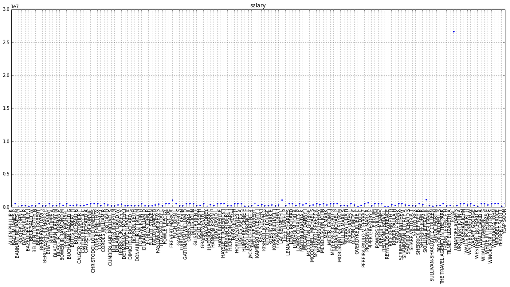

```python
column='salary'
print df[[column]].sort([column], ascending=[0]).head(3)
plt.figure(figsize=(20,8))
df[column].plot(style='.')
x = range(len(df[column]))
plt.xticks(x,df.index)
locs, labels = plt.xticks()
print labels
plt.setp(labels, rotation=90)
plt.title(column)
plt.show()
```

After plotting the employee salaries, it's clear the Total is an aggregate and it should be dropped as well.

```python
df.drop('TOTAL', 0,inplace=True)
```

```
                     salary
SKILLING JEFFREY K  1111258
LAY KENNETH L       1072321
FREVERT MARK A      1060932
                    salary
WESTFAHL RICHARD K   63744
GRAY RODNEY           6615
BANNANTINE JAMES M     477
<a list of 144 Text xticklabel objects>
```

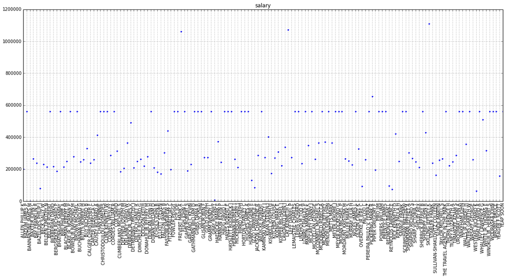

```python
column='salary'
print df[[column]].sort([column], ascending=[0]).head(3)
print df[[column]].sort([column], ascending=[0]).tail(3)
plt.figure(figsize=(20,8))
df[column].plot(style='.')
x = range(len(df[column]))
plt.xticks(x,df.index)
locs, labels = plt.xticks()
print labels
plt.setp(labels, rotation=90)
plt.title(column)
plt.show()
```

In the salary plot, I notice 'THE TRAVEL AGENCY IN THE PARK' is not an employee.

```python
df.drop('THE TRAVEL AGENCY IN THE PARK', 0,inplace=True)
```

```python
## Uncomment to plot all features.... This was used to review and eliminate outliers.

# for column in list(df):
#     if column not in ['email_address','poi','director_fees']:
#         if column not in ['email_address','poi']:
#             print df[[column]].sort([column], ascending=[0]).head(3)
#             plt.figure(figsize=(20,8))
#             df[column].plot(style='.')
#             x = range(len(df[column]))
#             plt.xticks(x,df.index)
#             locs, labels = plt.xticks()
#             print labels
#             plt.setp(labels, rotation=90)
#             plt.title(column)
#             plt.show()

#             plt.figure(figsize=(24,8))
#             plt.hist(df[column])
#             plt.title(column)
#             plt.show()
```

First, I created a new feature to_poi_ratio. My belief is sending a high number emails to a POI likely means the person is also involved in fruad. Next, let's determine which feature should be included in the model.

```python
df['to_poi_ratio'] = df['from_this_person_to_poi']/df['from_messages']
my_dataset = df.T.to_dict('dict')

features_list = [
 'bonus',
 'deferral_payments',
 'deferred_income',
 'director_fees',
 'exercised_stock_options',
 'expenses',
 'from_messages',
 'from_poi_to_this_person',
 'from_this_person_to_poi',
 'loan_advances',
 'long_term_incentive',
 'other',
 'poi',
 'restricted_stock',
 'restricted_stock_deferred',
 'salary',
 'shared_receipt_with_poi',
 'to_messages',
 'total_payments',
 'total_stock_value',
 'to_poi_ratio'
]



### Extract features and labels from dataset for local testing
data = featureFormat(my_dataset, features_list, sort_keys = True)
labels, features = targetFeatureSplit(data)

selector = SelectKBest(k='all').fit(features, labels).scores_
for score, feature in sorted(zip(selector, features_list[1:]), reverse=True):
    print feature, score
```

```
total_payments 41.680488503
other 7.17239506393
restricted_stock 7.01307459949
shared_receipt_with_poi 5.94609729241
to_messages 5.01738362412
from_poi_to_this_person 4.90355854018
total_stock_value 4.55401592279
loan_advances 3.82761495667
exercised_stock_options 2.77834660947
salary 2.76912309212
poi 2.64799556855
deferred_income 2.47584204945
from_this_person_to_poi 2.23895916453
long_term_incentive 1.66153616465
deferral_payments 1.41198631242
to_poi_ratio 1.30316886529
expenses 1.2002177662
from_messages 0.845972574964
director_fees 0.369305950015
restricted_stock_deferred 0.0426148900255
```

```python
features_list = [
             'poi',
             'bonus',
             'deferral_payments',
             'deferred_income',
             #'director_fees',
             'exercised_stock_options',
             'expenses',
             #'from_messages',
             'from_poi_to_this_person',
             'from_this_person_to_poi',
             'loan_advances',
             'long_term_incentive',
             'other',
             'restricted_stock',
             #'restricted_stock_deferred',
             'salary',
             'shared_receipt_with_poi',
             'to_messages',
             'total_payments',
             'total_stock_value'
                ]



### Extract features and labels from dataset for local testing
data = featureFormat(my_dataset, features_list, sort_keys = True)
labels, features = targetFeatureSplit(data)
```

# Analysis Validation and Performance

Using an example for the sklearn documenation, I decided to test LinearSVC and GaussianNB using Principal Component Analysis (PCA) and . Principal Component Analysis (PCA) anad Linear Discriminant Analysis (LDA). PCA identifies the combination of attributes (principal components, or directions in the feature space) that account for the most variance in the data. Linear Discriminant Analysis (LDA) tries to identify attributes that account for the most variance between classes. In particular, LDA, in contrast to PCA, is a supervised method, using known class labels.

http://scikit-learn.org/stable/auto_examples/decomposition/plot_pca_vs_lda.html

Based on the size and distribution of the dataset, Sklearn’s StratifiedShuffleSplit function was used to perform validation and capture performance measures. For 1000 folds, StratifiedShuffleSplit splits the dataset into two parts: training and testing sets. First, the training dataset is passed to the algorithm using fit. Then, the test dataset is passed to predict. Last, the results of predict is evaluated for each employee to determine if the outcome is a true positive, true negative, false positive, or false negative. After all 1000 folds are completed, the precision and recall is calculated.

```python
### Task 4: Try a varity of classifiers
### Please name your classifier clf for easy export below.
### Note that if you want to do PCA or other multi-stage operations,
### you'll need to use Pipelines. For more info:
### http://scikit-learn.org/stable/modules/pipeline.html
dict_all = {}
dict_pca = {}
dict_lda = {}
names = [
   "Linear_SVC",
   "Naive_Bayes"]

classifiers = [
    LinearSVC(),
    GaussianNB()]
```

```python
print "With StandardScaler"
for name, clf in zip(names, classifiers):
    clf_all = Pipeline(steps=[
       ('scaler', StandardScaler()),
       ('classification', clf)
    ])
    dict_all[name] =  output_classifier(clf_all, my_dataset, features_list)
all = pd.DataFrame.from_dict(dict_all, orient='index')
all
```

```
With StandardScaler
```

|  | recall | f1 | f2 | precision | accuracy |
| --- | --- | --- | --- | --- | --- |
| Linear_SVC | 0.174 | 0.248128 | 0.197615 | 0.432298 | 0.8594 |
| Naive_Bayes | 0.204 | 0.178947 | 0.193182 | 0.159375 | 0.7504 |

```python
print "With StandardScaler and PCA"
for name, clf in zip(names, classifiers):
    clf_pca = Pipeline(steps=[
       ('scaler', StandardScaler()),
       ('reduce_dim', PCA(n_components=1)),
       ('classification', clf)
     ])
    dict_pca[name] =  output_classifier(clf_pca, my_dataset, features_list)
pca = pd.DataFrame.from_dict(dict_pca, orient='index')
pca
```

```
With StandardScaler and PCA
```

|  | recall | f1 | f2 | precision | accuracy |
| --- | --- | --- | --- | --- | --- |
| Linear_SVC | 0.0405 | 0.077847 | 0.050118 | 1.000000 | 0.872067 |
| Naive_Bayes | 0.1525 | 0.226935 | 0.175529 | 0.443314 | 0.861467 |

```python
print "With StandardScaler and LDA"
for name, clf in zip(names, classifiers):
    clf_lda = Pipeline(steps=[
       ('scaler', StandardScaler()),
       ('reduce_dim', LDA(n_components=1)),
       ('classification', clf)
    ])
    dict_lda[name] =  output_classifier(clf_lda, my_dataset, features_list)
lda = pd.DataFrame.from_dict(dict_lda, orient='index')
lda
```

```
With StandardScaler and LDA
```

|  | recall | f1 | f2 | precision | accuracy |
| --- | --- | --- | --- | --- | --- |
| Linear_SVC | 0.1815 | 0.263521 | 0.207310 | 0.480795 | 0.864733 |
| Naive_Bayes | 0.2160 | 0.273418 | 0.235808 | 0.372414 | 0.846933 |

```python
### Task 5: Tune your classifier to achieve better than .3 precision and recall
### using our testing script.
### Because of the small size of the dataset, the script uses stratified
### shuffle split cross validation. For more info:
### http://scikit-learn.org/stable/modules/generated/sklearn.cross_validation.StratifiedShuffleSplit.html



clf = Pipeline([
    ('scaler', StandardScaler()),
    ('kbest', SelectKBest()),
    ('lda', LDA()),
    ('classification',GaussianNB() ),
])


parameters = {
    'kbest__score_func'         : (f_classif, f_regression),
    'kbest__k'                  : range(5,len(features_list)),
    'lda__n_components'         : (1,2,3,4),
    'lda__store_covariance'     : (True, False),
    'lda__tol'                  : (0.0001,0.001)
}

grid = GridSearchCV(clf,parameters,n_jobs=-1)
grid.fit(features, labels)
clf = grid.best_estimator_

print clf
```

```
Pipeline(steps=[('scaler', StandardScaler(copy=True, with_mean=True, with_std=True)), ('kbest', SelectKBest(k=5, score_func=<function f_classif at 0x108f69c08>)), ('lda', LDA(n_components=1, priors=None, shrinkage=None, solver='svd',
  store_covariance=True, tol=0.0001)), ('classification', GaussianNB())])
```

```python
selector = SelectKBest(k=5,score_func=f_classif).fit(features, labels).scores_
for score, feature in sorted(zip(selector, features_list[1:]), reverse=True):
    print feature
```

[output not shown]

```python
features_list = [
             'poi',
             'exercised_stock_options',
             'total_stock_value',
             'to_poi_ratio',
             'bonus',
             'salary'
     ]


### Extract features and labels from dataset for local testing
data = featureFormat(my_dataset, features_list, sort_keys = True)
labels, features = targetFeatureSplit(data)
```

```python
### Dump your classifier, dataset, and features_list so
### anyone can run/check your results.

clf = Pipeline(steps=[('scaler', StandardScaler(copy=True, with_mean=True, with_std=True)),
                      ('lda', LDA(n_components=1, priors=None, shrinkage=None, solver='svd',
  store_covariance=True, tol=0.0001)), ('classification', GaussianNB())])

test_classifier(clf, my_dataset, features_list,folds=1000)

dump_classifier_and_data(clf, my_dataset, features_list)
```

```
Pipeline(steps=[('scaler', StandardScaler(copy=True, with_mean=True, with_std=True)), ('lda', LDA(n_components=1, priors=None, shrinkage=None, solver='svd',
  store_covariance=True, tol=0.0001)), ('classification', GaussianNB())])
	Accuracy: 0.88240	Precision: 0.60906	Recall: 0.32950	F1: 0.42764	F2: 0.36281
	Total predictions: 15000	True positives:  659	False positives:  423	False negatives: 1341	True negatives: 12577
```

# Discussion and Conclusions

I found it difficult to understand the difference between Precision and Recall until I read the article 8 out of 10 brown cats. Then, for whatever reason, it clicked. Recall and precision measure the quality of your result. The algorithm results are one of the following:

classified correctly true positive (TP): a POI predicted as a POI true negative (TN):a non-POI predicted as a non-POI misclassified false positive (FP): a non-POI which is predicted as a POI false negative (FN): a POI which is predicted as a non-POI

```
Formulas:
precision   = TP/TP+FP
recall      = TP/TP+FN
```

So, Can machine learning be used to Identify Fraud in Enron? Based on my findings, yes. With additional time, a better understanding of the dataset, and a few additional data points, the performance still could be improved.

### References:

http://www.referenceforbusiness.com/history2/57/Enron-Corporation.html

https://docs.google.com/document/d/1wCkOFWtGqOV7ira09NoZA7Otuf8SoUG2GuJUWmFbaQk/pub

http://harshtechtalk.com/model-hyperparameter-tuning-scikit-learn-using-gridsearch/

http://blog.kaggle.com/2015/07/16/scikit-learn-video-8-efficiently-searching-for-optimal-tuning-parameters/

http://scikit-learn.org/stable/modules/generated/sklearn.cross_validation.StratifiedShuffleSplit.html

http://scikit-learn.org/stable/tutorial/machine_learning_map/index.html

http://stackoverflow.com/questions/332289/how-do-you-change-the-size-of-figures-drawn-with-matplotlib

https://github.com/ipython-contrib/IPython-notebook-extensions/wiki/Comment-uncomment

https://medium.com/seek-product-management/8-out-of-10-brown-cats-6e39a22b65dc

http://zacstewart.com/2014/08/05/pipelines-of-featureunions-of-pipelines.html